# (Communicate Data Finding : Ford GoBike System Data)

## by (Eng.Mohamed Mostafa)

## Preliminary Wrangling

### note

1- avarage age 36 years.

2- avarge trip duration 704 sec.

### What is the structure of your dataset?

> there are 174,952 records in the dataset with 12 features ( duration_sec , start_time , end_time , start_station_id , start_station_name , end_station_id , end_station_name , bike_id , user_type , member_birth_year , member_gender, age)

### What is/are the main feature(s) of interest in your dataset?

> 1-what is the avarage age of users?

> 2-what is the most user type ?

> 3-what is the most gender ?

> 4- what is the most day of the week ?

> 5-what the relationshipe between Age and trip duration ?

> 6-what the gender majorty users and majorty users type ?

> 7-what the most Day of the week for the users gender and users Types ?

### What features in the dataset do you think will help support your investigation into your feature(s) of interest?

> Trip Duration (seconds), Start Time and Date , End Time and Date, User Type , Member Year of Birth , Member Gender , age

## Univariate Exploration

> In this section, investigate distributions of individual variables. If you see unusual points or outliers, take a deeper look to clean things up and prepare yourself to look at relationships between variables.

### figure 1 : " what is the avarage age of users ?"

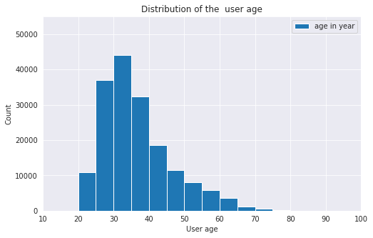

> We can see the the above plot is right-screwed, with a long tail on the right.

> the most user age from 30 :35 years

### figure 2 : " what is the most user type ?"

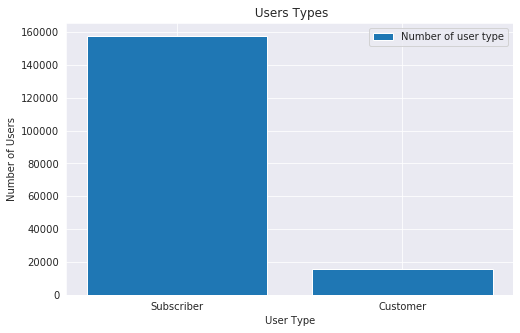

> We can see the the above plot is subscriber is the most user type

### figure 3 : " what is the most gender ?"

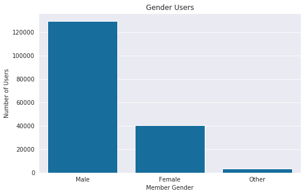

### figure 4 : " what is the most day of the week ?"

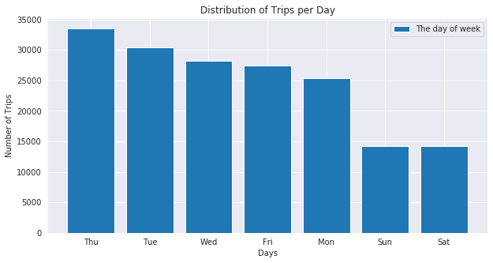

### Note

- clear from the above plot the thursday is most day of the week

## Bivariate Exploration

> we will see the correlation between (trip duration) and (age).

### figure 5 : " what the relationshipe between Age and trip duration ?"

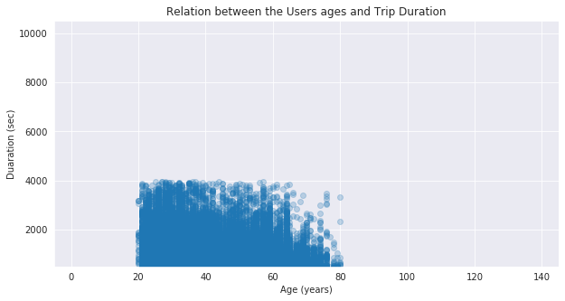

### figure 6 : " what the gender majorty users and majorty users type ?"

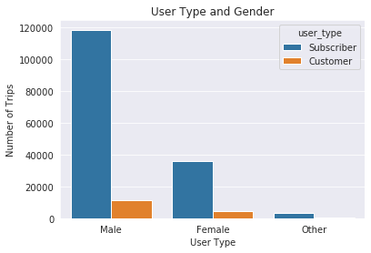

### Note

1- The male gender is the majorty User in gender .

2-Subscriber user customer is majorty User in type User .

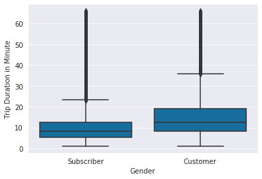

**Note : the avarge of duration for the custmer is higher than subscriber**

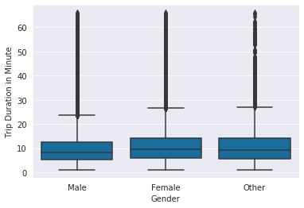

**the avarege of duration for male and female is nearly the same**

## Multivariate Exploration

### figure 7 : " what the most Day of the week for the users gender and users Types ?"

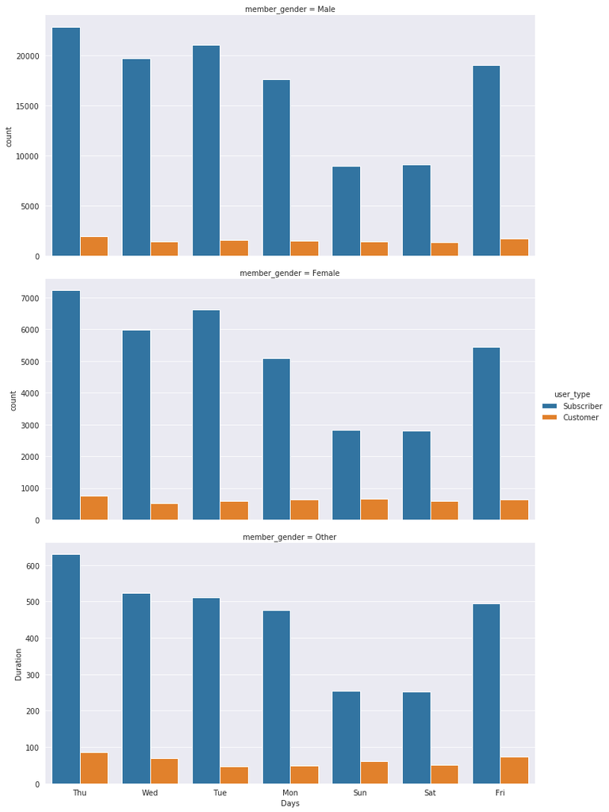

### Note

1- the thursday is most day of the week of users genders and users types

### Talk about some of the relationships you observed in this part of the investigation. Were there features that strengthened each other in terms of looking at your feature(s) of interest?

> It is clear in above figure the male is the most than the female

### Were there any interesting or surprising interactions between features?

> But also the ratio of the female from the total female > the ratio of the male from total male